# Manage Client Keys

[[edit on GitHub]](https://github.com/chef/chef-web-docs/blob/main/content/server_manage_clients.md)

[figure not shown]

Warning

Chef Manage is deprecated and no longer under active development. It is supported on Chef Automate installations up to version 1.8 and replaced by Chef Automate 2.0. Contact your Chef account representative for information about upgrading your system. See our Automate documentation to learn more about Chef Automate 2.

This document is no longer maintained.

Note

This topic is about using the Chef management console to manage keys.

A client is an actor that has permission to access the Chef Infra Server. A client is most often a node (on which the Chef Infra Client runs), but is also a workstation (on which knife runs), or some other machine that is configured to use the Chef Infra Server API. Each request to the Chef Infra Server that is made by a client uses a private key for authentication that must be authorized by the public key on the Chef Infra Server.

Use the Chef management console to create a key pair, download the private key, and then set permissions, to delete a key, or to reset a key.

## Manage Client Keys

Client keys can be managed from the Chef management console.

Warning

The images below refer to client keys as a “Client”.

### Add

To add a client key:

1. Open the Chef management console.
2. Click **Policy**.
3. Click **Clients**.
4. Click **Create**.
5. In the **Create Client** dialog box, enter the name of the client key.

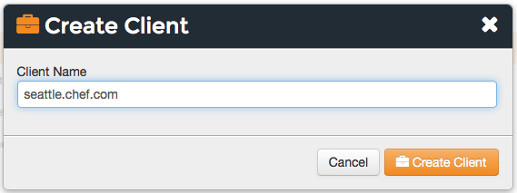

   Click **Create Client**.
6. Copy the private key:

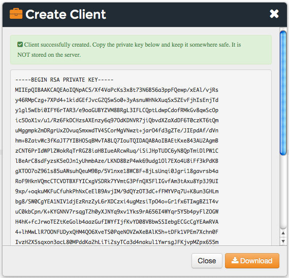

   or download and save the private key locally:

[figure not shown]

### Delete

To delete a client key:

1. Open the Chef management console.
2. Click **Policy**.
3. Click **Clients**.
4. Select a client key.
5. Click **Delete**.

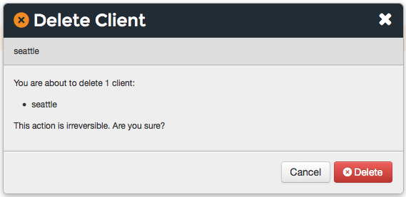

### Reset Key

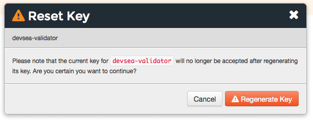

8. Copy the private key:

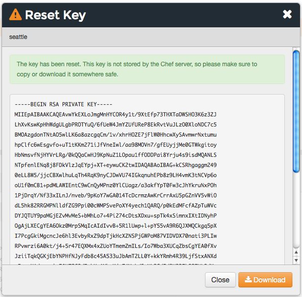

   or download and save the private key locally:

[figure not shown]

### View Details

To view client key details:

1. Open the Chef management console.
2. Click **Policy**.
3. Click **Clients**.
4. Select a client key.
5. Click the **Details** tab.

### Permissions

Permissions are used in the Chef Infra Server to define how users and groups can interact with objects on the server. Permissions are configured per-organization.

The Chef Infra Server includes the following object permissions:

[output not shown]

#### Set

To set permissions list for a client key:

1. Open the Chef management console.
2. Click **Policy**.
3. Click **Clients**.
4. Select a client key.
5. Click the **Permissions** tab.
6. For each group listed under **Name**, select or de-select the **Read**, **Update**, **Delete**, and **Grant** permissions.

#### Update

To update the permissions list for a client key:

1. Open the Chef management console.
2. Click **Policy**.
3. Click **Clients**.
4. Select a client key.
5. Click the **Permissions** tab.
6. Click the **+ Add** button and enter the name of the user or group to be added.
7. Select or de-select **Read**, **Update**, **Delete**, and **Grant** to update the permissions list for the user or group.

#### View

To view permissions for a client key:

1. Open the Chef management console.
2. Click **Policy**.
3. Click **Clients**.
4. Select a client key.
5. Click the **Permissions** tab.
6. Set the appropriate permissions: **Delete**, **Grant**, **Read**, and/or **Update**.

## chef-validator Keys

Every request made by Chef Infra Client to the Chef Infra Server must be an authenticated request using the Chef Infra Server API and a private key. When Chef Infra Client makes a request to the Chef Infra Server, Chef Infra Client authenticates each request using a private key located in `/etc/chef/client.pem`.

The private key does not yet exist the first time that Chef Infra Client runs from a new node.

During the first Chef Infra Client run:

1. Chef Infra Client uses the chef-validator private key, located in `/etc/chef/validation.pem` to register with Chef Infra Server
2. Chef Infra Server assigns Chef Infra Client a private key for all future authentication requests to the Chef Infra Server
3. Chef Infra Client saves the private key on the node as `/etc/chef/client.pem`

If the request to communicate with Chef Infra Server with the chef-validator key fails, then the entire first Chef Infra Client run fails.

After the first completed Chef Infra Client run, delete the chef-validator private key at `/etc/chef/validation.pem`

### Add

To add a chef-validator key:

1. Open the Chef management console.
2. Click **Policy**.
3. Click **Clients**.
4. Click **Create**.
5. In the **Create Client** dialog box, enter the name of the chef-validator key.

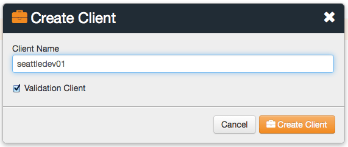

   Select the **Validation Client** option. Click **Create Client**.
6. Copy the private key:

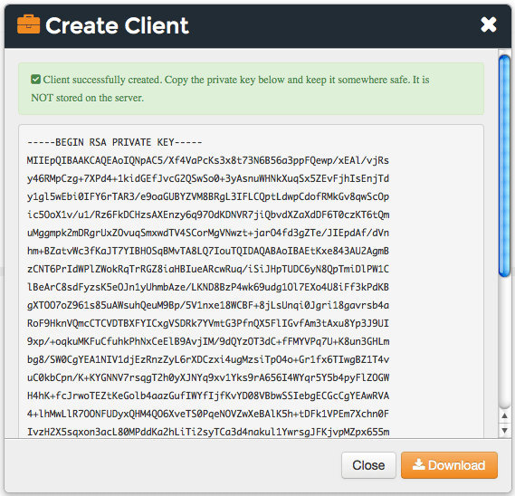

   or download and save the private key locally:

[figure not shown]

### Delete

To delete a chef-validator key:

1. Open the Chef management console.
2. Click **Policy**.
3. Click **Clients**.
4. Select a chef-validator key.
5. Click **Delete**.

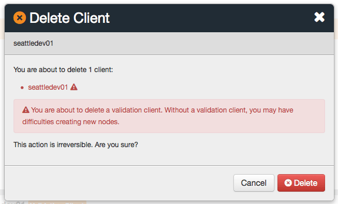

### Reset Key

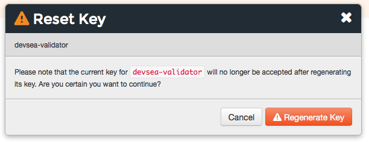

8. Copy the private key:

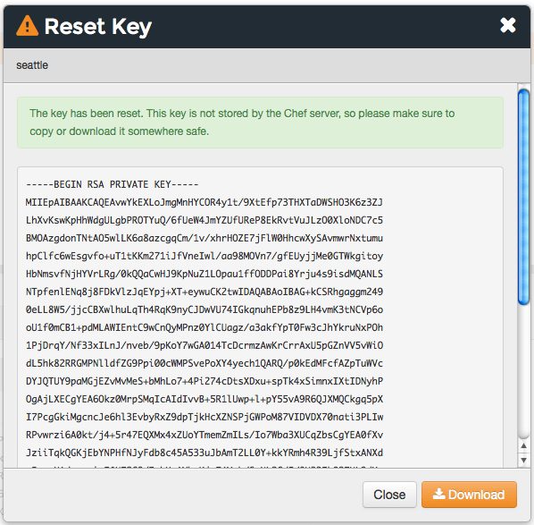

   or download and save the private key locally:

[figure not shown]

### View Details

To view details for a chef-validator key:

1. Open the Chef management console.
2. Click **Policy**.
3. Click **Clients**.
4. Select a chef-validator key.

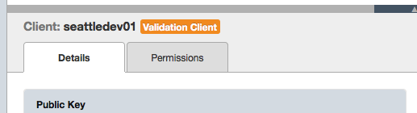

5. Click the **Details** tab.

### Permissions

Permissions are used in the Chef Infra Server to define how users and groups can interact with objects on the server. Permissions are configured per-organization.

The Chef Infra Server includes the following object permissions:

[output not shown]

#### Set

To update the permissions list for a chef-validator key:

1. Open the Chef management console.
2. Click **Policy**.
3. Click **Clients**.
4. Select a chef-validator key.
5. Click the **Permissions** tab.
6. Click the **+ Add** button and enter the name of the user or group to be added.
7. Select or de-select **Delete**, **Grant**, **Read**, and/or **Update** to update the permissions list for the user or group.

#### Update

To update the permissions list for a client key:

1. Open the Chef management console.
2. Click **Policy**.
3. Click **Clients**.
4. Select a client key.
5. Click the **Permissions** tab.
6. Click the **+ Add** button and enter the name of the user or group to be added.
7. Select or de-select **Read**, **Update**, **Delete**, and **Grant** to update the permissions list for the user or group.

#### View

To view permissions for a chef-validator key:

1. Open the Chef management console.
2. Click **Policy**.
3. Click **Clients**.
4. Select a chef-validator key.
5. Click the **Permissions** tab.
6. Set the appropriate permissions: **Delete**, **Grant**, **Read**, and/or **Update**.